# Visualization in R

Lizzie Kumar & Isha Raut  
April 2, 2018

### ggplot2

- Library in R that makes nice graphics
- Makes creation of good looking, useful graphics much easier than base R
- Consistent with a *grammar of graphics*

### ggplot2

Plot = Data + Aesthetics + Geometric Objects

### Definitions: Aesthetics

Mapping of information to a visual property

- Categorical -> Color
- Numerical -> Position
- …

### Definitions: Aesthetics

Mapping of information to a visual property

- Categorical -> Color
- Numerical -> Position
- Categorical -> Shape
- Numerical -> Color
- Numerical -> Size
- Numerical -> Transparency
- …

### Definitions: Geoms

A geometric object

- Point
- Line
- …

### Definitions: Geoms

A geometric object

- Point
- Line
- Bar
- Box-and-whisker
- Polygon
- …

### Set Up

```r
# install.packages('ggplot2')
library('ggplot2')
```

### Data

```r
# install.packages('nycflights13')
# install.packages('dplyr')
library(tidyverse)
library(nycflights13)
library(dplyr)
head(flights)
```

```
# A tibble: 6 x 19
   year month   day dep_time sched_dep_time dep_delay arr_time
  <int> <int> <int>    <int>          <int>     <dbl>    <int>
1  2013     1     1      517            515        2.      830
2  2013     1     1      533            529        4.      850
3  2013     1     1      542            540        2.      923
4  2013     1     1      544            545       -1.     1004
5  2013     1     1      554            600       -6.      812
6  2013     1     1      554            558       -4.      740
# ... with 12 more variables: sched_arr_time <int>, arr_delay <dbl>,
#   carrier <chr>, flight <int>, tailnum <chr>, origin <chr>, dest <chr>,
#   air_time <dbl>, distance <dbl>, hour <dbl>, minute <dbl>,
#   time_hour <dttm>
```

### A typical ggplot2 call & translation

```r
ggplot(flights, aes(x = dep_delay, y = arr_delay)) +
  geom_point() +
  geom_smooth()
```

We pass *data* into the ggplot function, add *geoms* separated by `+`, and specify *aesthetics* with `aes()`

### Basic Plots

- Scatter Plot
- Line Chart
- Bar Chart
- Histogram
- Density Plot
- Box Plot

### Initialization

- Initialize empty graphic
- We will add our plot to this base plot
- Feed base plot data, x and y values

### Initialization Continued

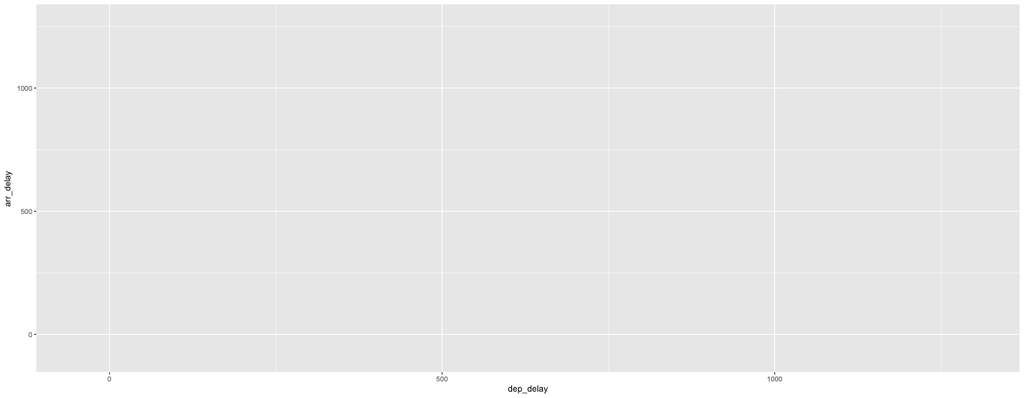

```r
plot <- ggplot(flights, aes(x = dep_delay, y = arr_delay))
plot
```

We have specified aesthetics, but haven't added any geoms! Tip: Specify aesthetics in the main ggplot call to keep the mapping consistent across different geoms

### Scatter Plot

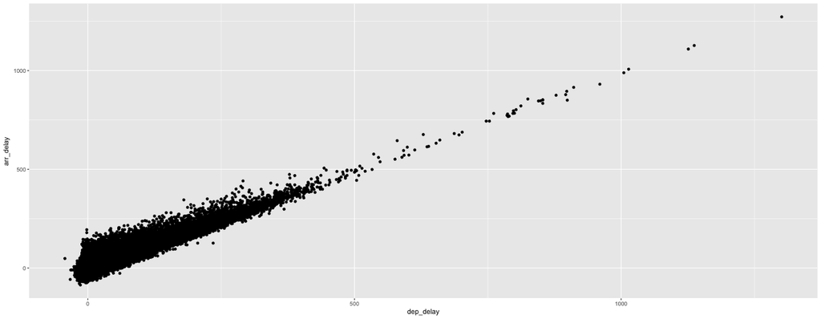

```r
plot + geom_point()
```

### Scatter Plot Continued

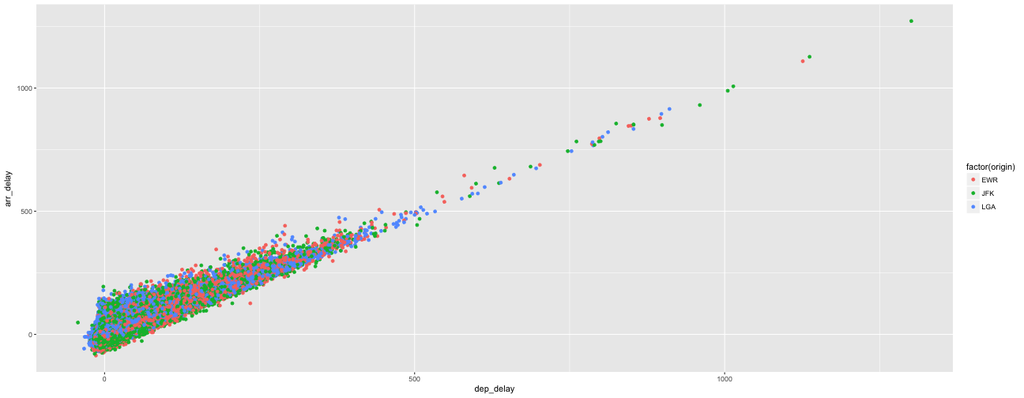

```r
plot + geom_point(aes(color = factor(origin)))
```

We can also add aesthetic mappings for individual geoms using aes()

### Scatter Plot Continued

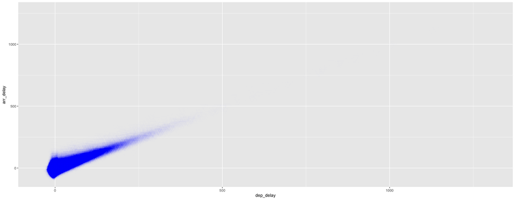

```r
plot + geom_point(color = 'blue', size = 5, shape = 25, alpha = .01)
```

We can hard-code values within geoms by passing them in as arguments WITHOUT using aes()

### Scatter Plot Continued

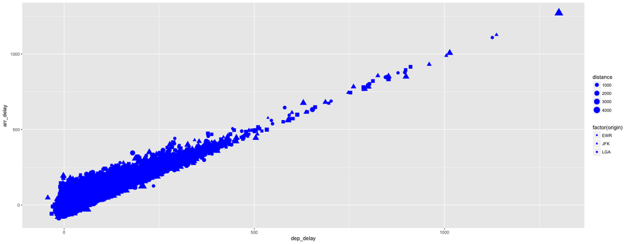

```r
plot + geom_point(aes(size = distance, shape = factor(origin)), color = 'blue')
```

### Line Chart

```r
plot + geom_point() + geom_smooth()
```

[output not shown]

Some geoms do *statistical transformations* on the data that can be further configured

### Line Chart Continued

```r
plot + geom_point() + geom_smooth(span = .01)
```

[output not shown]

### Line Chart Continued

```r
plot + geom_point() + geom_smooth(span = .9)
```

[output not shown]

### Line Chart Continued

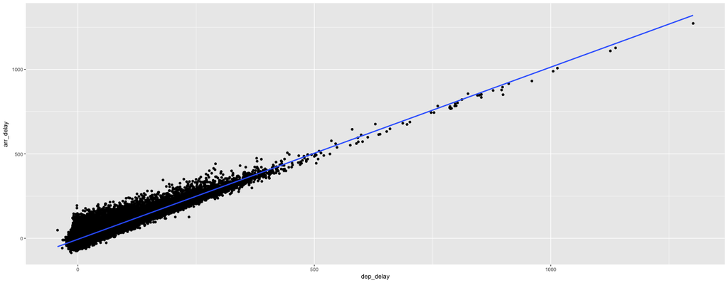

```r
plot + geom_point() + geom_smooth(method = 'lm')
```

### Line Chart Continued

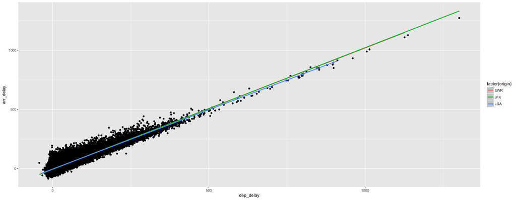

```r
plot + geom_point() + geom_smooth(aes(color = factor(origin)), method = 'lm')
```

### Box Plot

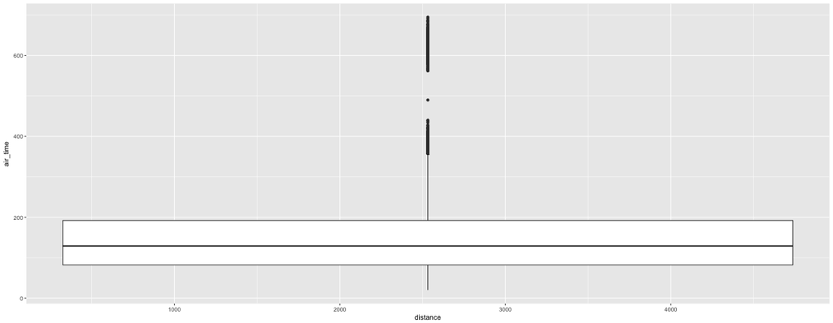

```r
plot2 <- ggplot(flights, aes(distance, air_time))
plot2 + geom_boxplot()
```

### Box Plot Continued

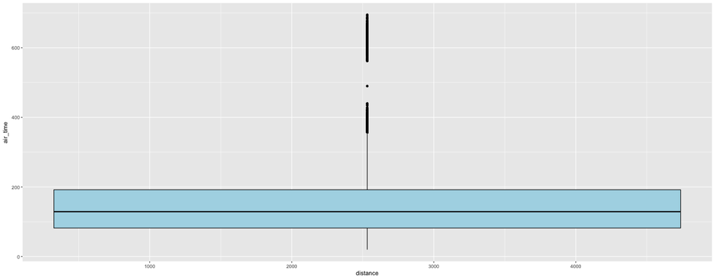

```r
plot2 + geom_boxplot(fill = 'lightblue', colour = 'black')
```

### Box Plot Continued

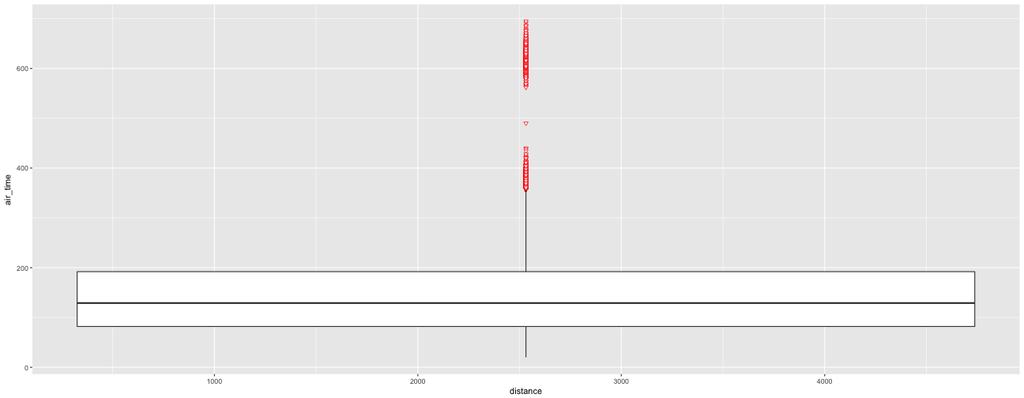

```r
plot2 + geom_boxplot(outlier.colour = 'red', outlier.shape = 25)
```

### Box Plot Continued

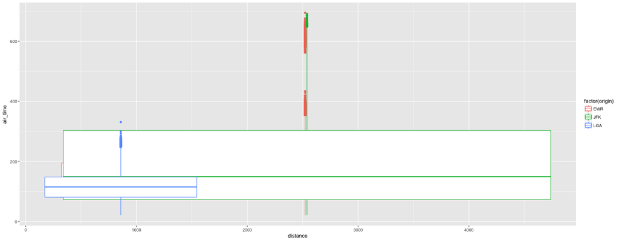

```r
plot2 + geom_boxplot(aes(color = factor(origin)))
```

### Bar Chart

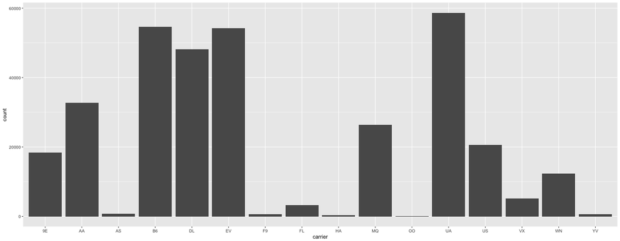

```r
plot <- ggplot(flights, aes(carrier))
plot + geom_bar()
```

### Bar Chart Continued

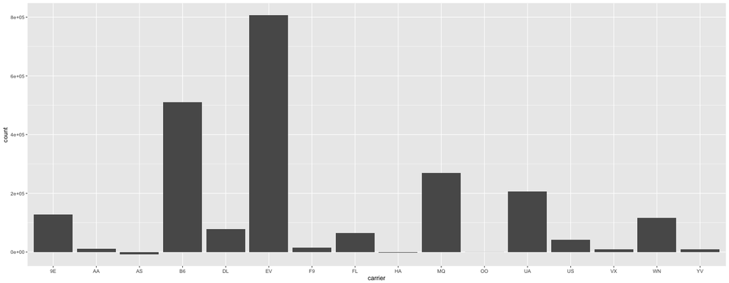

```r
plot + geom_bar(aes(weight = arr_delay))
```

### Bar Chart Continued

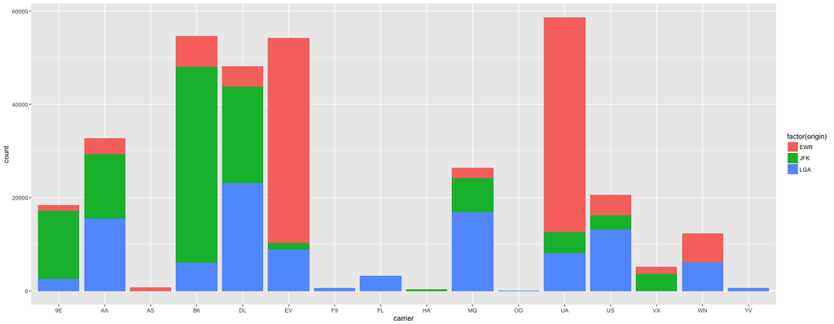

```r
plot + geom_bar(aes(fill = factor(origin)))
```

### Bar Chart Continued

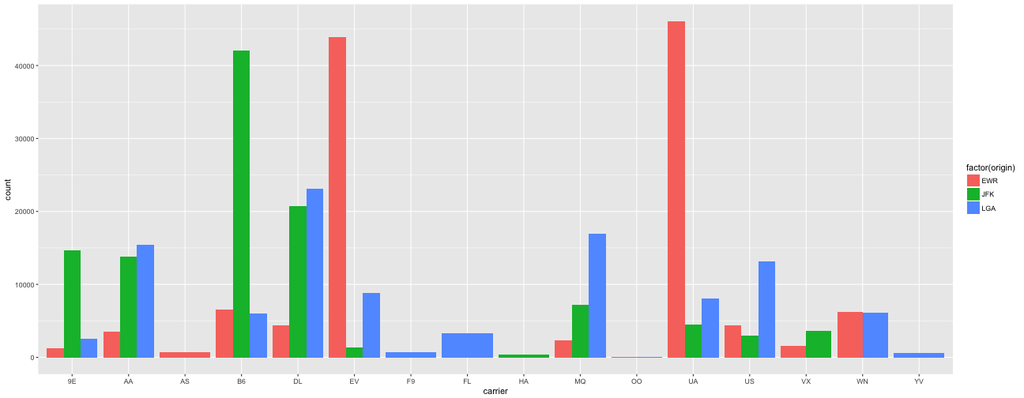

```r
plot + geom_bar(aes(fill = factor(origin)), position = 'dodge')
```

### Bar Chart Continued

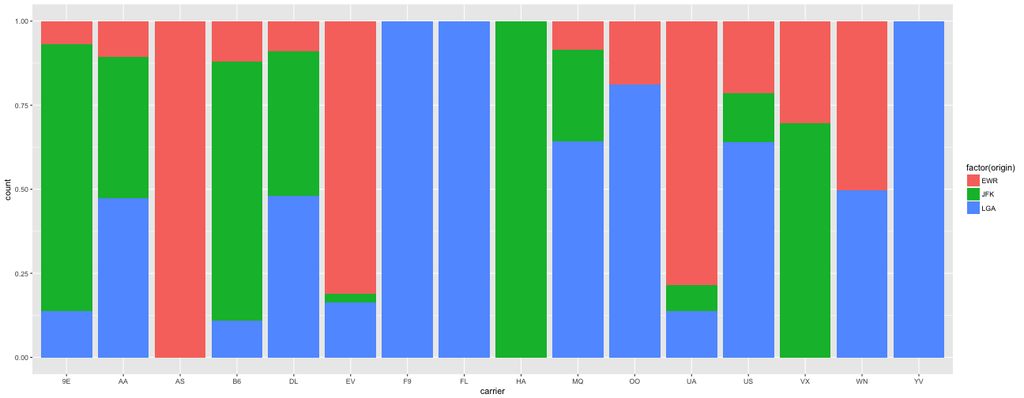

```r
plot + geom_bar(aes(fill = factor(origin)), position = 'fill')
```

### Histogram

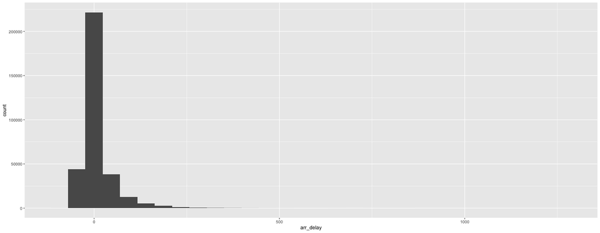

```r
plot <- ggplot(flights, aes(arr_delay))
plot + geom_histogram()
```

### Histogram Continued

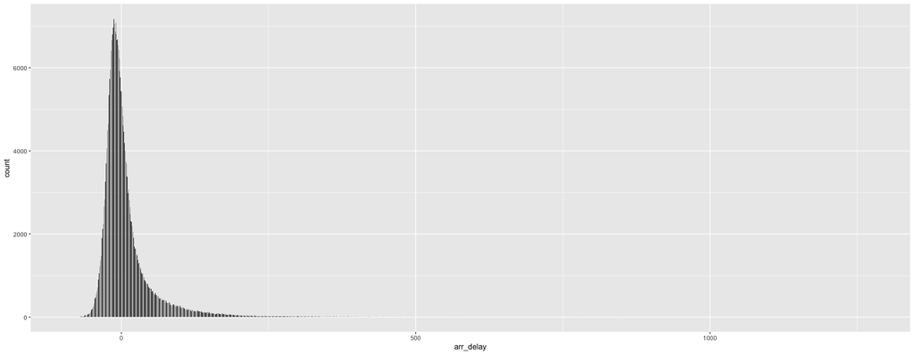

```r
plot + geom_histogram(binwidth = 0.5)
```

### Histogram Continued

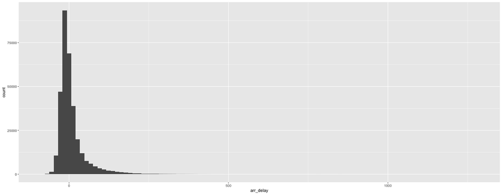

```r
plot + geom_histogram(bins = 100)
```

### Histogram Continued

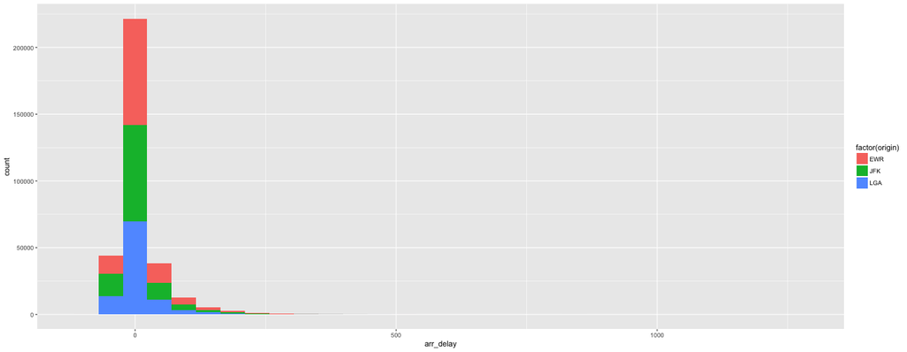

```r
plot + geom_histogram(aes(fill = factor(origin)))
```

### Histogram Continued

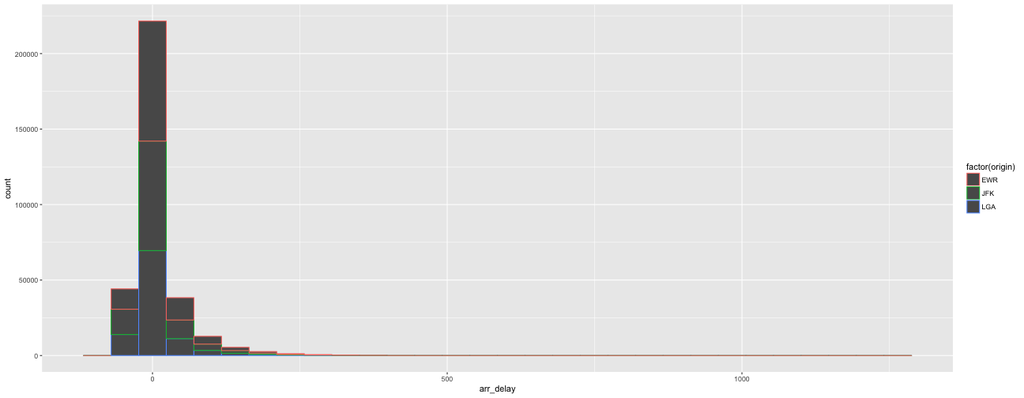

```r
plot + geom_histogram(aes(color = factor(origin)))
```

### Density Chart

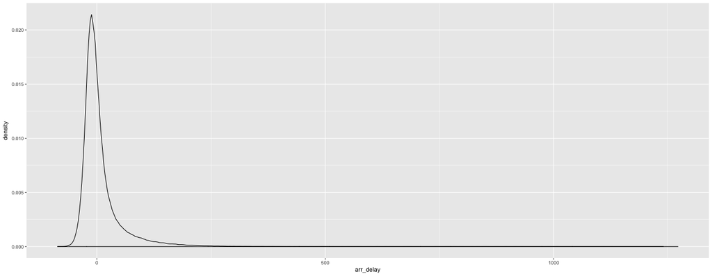

```r
plot + geom_density()
```

### Density Chart Continued

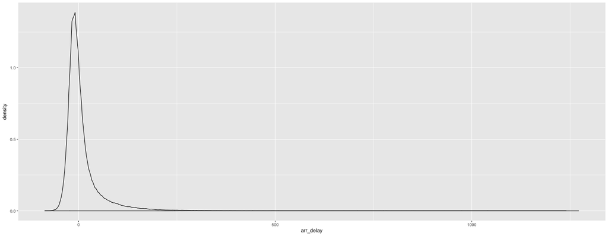

```r
plot + geom_density(adjust = .01)
```

### Density Chart Continued

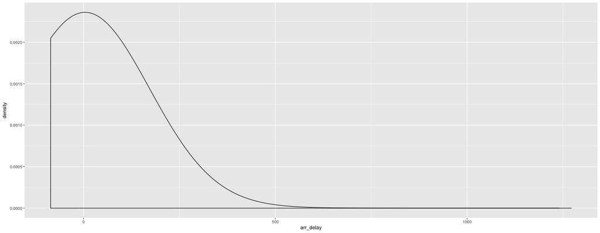

```r
plot + geom_density(adjust = 100)
```

### Density Chart Continued

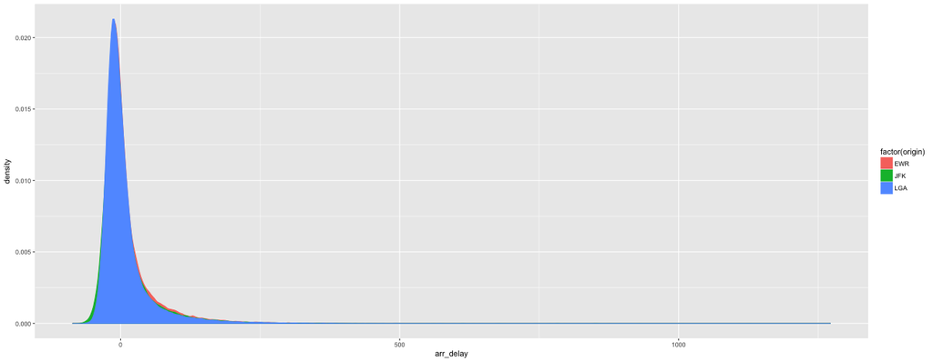

```r
plot + geom_density(aes(color = factor(origin), fill = factor(origin)))
```

### Density Chart Continued

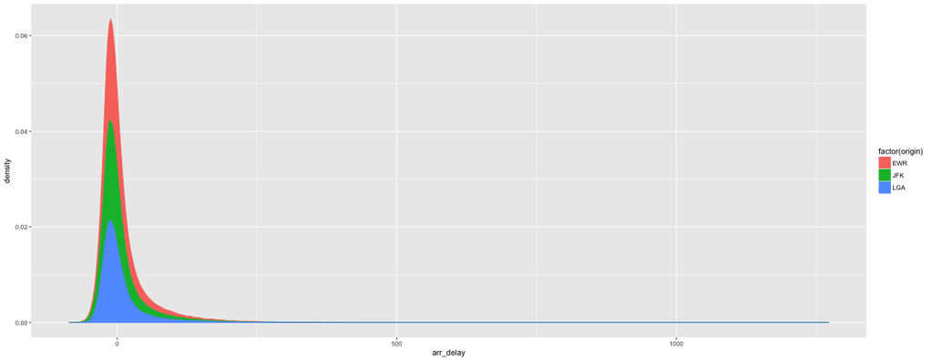

```r
plot + geom_density(aes(color = factor(origin), fill = factor(origin)), position = 'stack')
```

### Density Chart Continued

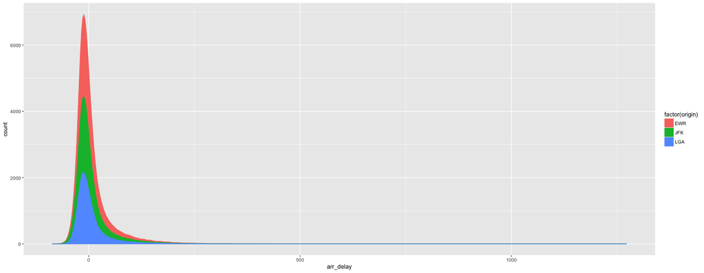

```r
ggplot(flights, aes(arr_delay, ..count.., color = factor(origin),
                    fill = factor(origin))) +
  geom_density(position = 'stack')
```

### Some additional options

- `... + xlim(c(1, 10)) + ylim(c(50, 100)`: crop X and/or Y axis
- `... + facet_wrap(~carrier)`: make subplots by factor value

### Finishing Touches

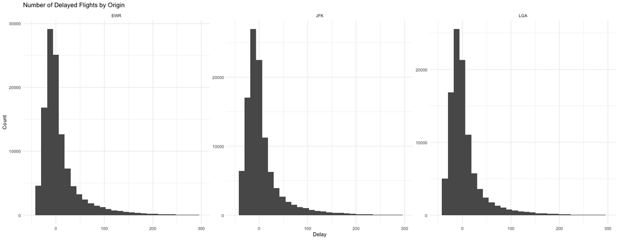

```r
ggplot(flights, aes(arr_delay)) +
  geom_histogram() +
  xlim(c(-50, 300)) +
  facet_wrap(~origin, scales = 'free_y') +
  ylab('Count') + xlab('Delay') +
  ggtitle('Number of Delayed Flights by Origin') +
  theme_minimal()
```

Use `ggsave(filename)` to save the most recently displayed plot to a file!

### How to Get Help

In the console, type `?geom_point` to pull up documentation on a geom or function…

or browse the full documentation at `http://ggplot2.tidyverse.org/reference/` …

### Exercises

### Other topics

- Interaction : making your ggplots interactive!
- Other fun graphs : Maps!

### Plotly and ggplot

```r
library("plotly")
ggflights<- ggplot2::ggplot(flights, aes(arr_delay, ..count.., colour=factor(origin),fill = factor(origin))) + geom_density(position='stack')

#ggplotly(ggflights)
```

### Maps

```r
# install.packages('maps')
# install.packages('choroplethr')
require(maps)
require(choroplethr)
data(df_state_demographics)
states <- map_data('state')
data <- merge(df_state_demographics, states, by='region')
```

### Map Data

```r
head(data)
```

```
   region total_population percent_white percent_black percent_asian
1 alabama          4799277            67            26             1
2 alabama          4799277            67            26             1
3 alabama          4799277            67            26             1
4 alabama          4799277            67            26             1
5 alabama          4799277            67            26             1
6 alabama          4799277            67            26             1
  percent_hispanic per_capita_income median_rent median_age      long
1                4             23680         501       38.1 -87.46201
2                4             23680         501       38.1 -87.48493
3                4             23680         501       38.1 -87.52503
4                4             23680         501       38.1 -87.53076
5                4             23680         501       38.1 -87.57087
6                4             23680         501       38.1 -87.58806
       lat group order subregion
1 30.38968     1     1      <NA>
2 30.37249     1     2      <NA>
3 30.37249     1     3      <NA>
4 30.33239     1     4      <NA>
5 30.32665     1     5      <NA>
6 30.32665     1     6      <NA>
```

### Basic Map

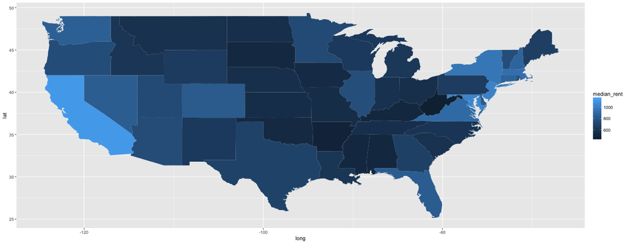

```r
plot <- ggplot(data, aes(long, lat))
plot + geom_polygon(aes(group=group, fill=median_rent))
```